# Exponential Coalescent Analyses

Nicola Mueller

2020-01-28

# Summary

- There is signal to estimate evolutionary rates in the data based on date randomization tests.
- The evolutionary rate of novel Coronavirus is estimated to be most likely somewhere between 1x10-3 and 2x10-3.
- The tMRCA is quite uncertain, but is inferred to most likely around the beginning of December using a constant coalescent and mid December using en exponential coalescent model.

## Estimating the evolutionary rate of novel Coronavirus

I here estimate the evolutionary rate of novel Coronavirus using different priors on the exponential growth rate. This is done with the same sequences as in https://nextstrain.org/ncov. I used a strict clock model and an HKY + Gamma4 site model, treating every site the same. Additionally, I only used the sites 1000-29000 from the aligned sequence file. For each of the analysis, the prior on the growth rate is normally distributed around 0 and the sigma of the normal distribution is varied. Using a sigma value 0.001 essentially assumes a constant population over time. For the exponential coalescent, I’ve used a normal distriubition around 0 and sigma=100 I compare these rate estimates when using the true dates (results in blue) of each sample and then compare it to the estimates when randomizing the tip dates. Randomizing the tip dates essentially removes the time information from the sequence data and therefore removes the possibility to correctly estimate these rates. This randomization is done 10 times and the results are shown in orange. When then estimating the evolutionary rates, the prior information about the population dynamics is dominating. This therefore tells us how much information about the evolutionary rates there is in the data in absence of the population prior. In the plots, the outer bars approx. correspond to 95% intervals.

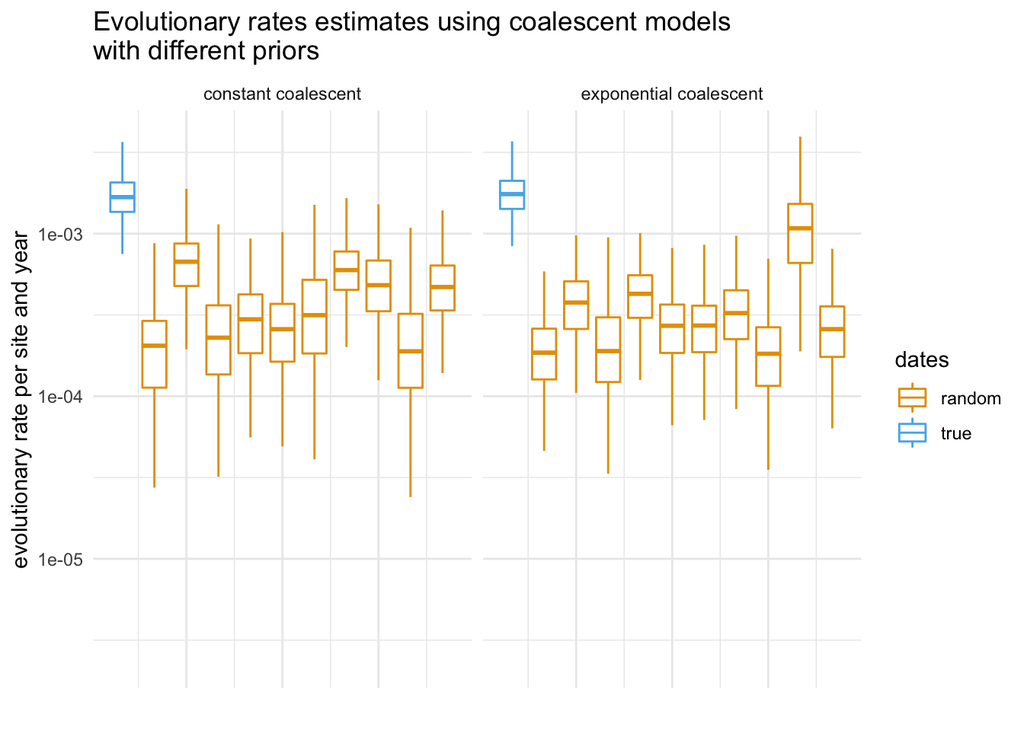

```r
expo_dat$x_offset = 1
expo_dat[which(expo_dat$dates=="true"), "x_offset"] = 0

p_evol = ggplot(expo_dat[which(expo_dat$masking==0), ]) +
  geom_boxplot(aes(y=clockRate, x=x_offset+date_rep, group=interaction(dates,date_rep), color=dates),outlier.shape = NA) +
  xlab("")+
  ylab("evolutionary rate per site and year")+
  scale_x_continuous(labels=c())+
  facet_wrap(~growth_prior, ncol=2) +
  scale_y_log10()+
  scale_color_OkabeIto()+
  theme_minimal()+
  ggtitle("Evolutionary rates estimates using coalescent models\nwith different priors")

plot(p_evol)
```

## Time of the most recent common ancestor using the coalescent with exponential growth

For all the scenarios where we used the true sampling dates, we also estimated the time of the most recent common ancestor of all sequences.

When assuming a constant population over time (constant coalescent), the tMRCA is inferred to be most likely at the beginning of December, while an exponentially growing population puts the tMRCA most likely somewhere mid December, but does not exlcude the beginning of December.

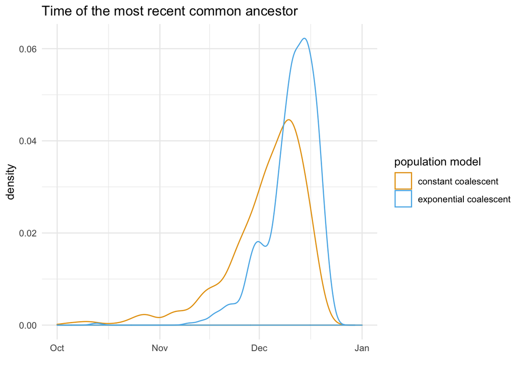

```r
p_tmrca = ggplot(expo_dat[which(expo_dat$masking==0 & expo_dat$dates=="true"), ]) +
  geom_density(aes(x=mrca, group=growth_prior, color=growth_prior)) +
  xlab("")+
  scale_x_date(limits=as.Date(c("2019-10-01", "2020-01-01")))+
  ggtitle("Time of the most recent common ancestor") +
  scale_color_OkabeIto(name=("population model"))+
  theme_minimal()
plot(p_tmrca)
```

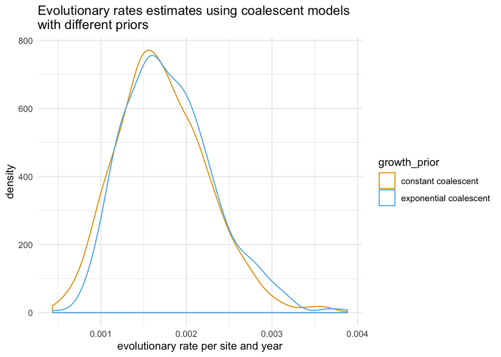

```r
p_evol = ggplot(expo_dat[which(expo_dat$masking==0 & expo_dat$dates=="true"), ]) +
  geom_density(aes(x=clockRate, color=growth_prior),outlier.shape = NA) +
  xlab("")+
  xlab("evolutionary rate per site and year")+
  scale_color_OkabeIto()+
  theme_minimal()+
  ggtitle("Evolutionary rates estimates using coalescent models\nwith different priors")

plot(p_evol)
```

## What is the tMRCA

The time of the most recent common ancestor (or tMRCA), denotes the time when all the sequenced cases in a dataset last shared a common ancestor. It does not, for example, denote when a virus first entered the human population. In fact, the earliest time possible of the MRCA is the time of the zoonosis, if all sequenced cases are from the human population and zoonosis occured only once.

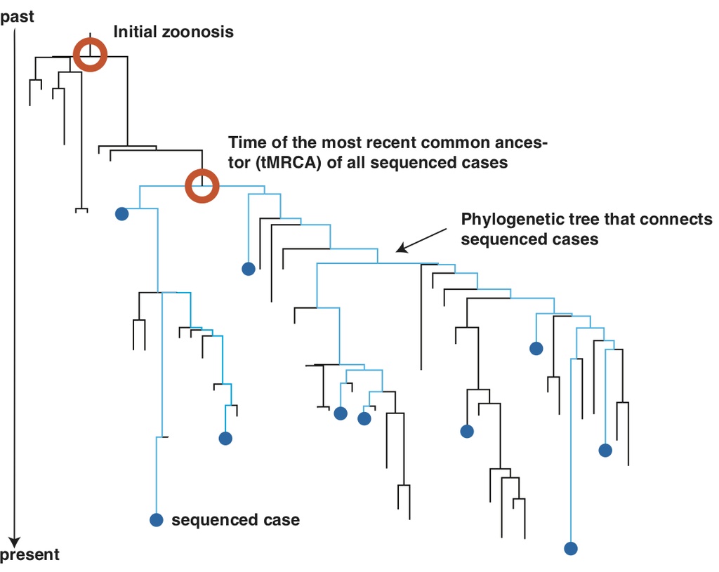

Example phylogeny where the time of the initial zoonosis is different from the most recent common ancestor of several sequenced cases

## Estimating the evolutionary rate of novel Coronavirus when allowing for base calling errors

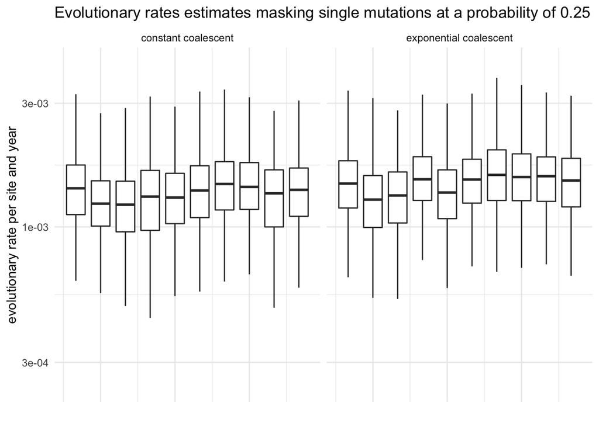

```r
expo_dat$x_offset = 10
expo_dat[which(expo_dat$dates=="true"), "x_offset"] = 0

p_evol = ggplot(expo_dat[which(expo_dat$masking==0.25), ]) +
  geom_boxplot(aes(y=clockRate, x=x_offset+date_rep+masking_rep, group=interaction(dates,date_rep,masking_rep)),outlier.shape = NA) +
  xlab("")+
  ylab("evolutionary rate per site and year")+
  scale_x_continuous(labels=c())+
  facet_wrap(~growth_prior, ncol=2) +
    scale_y_log10()+
  theme_minimal()+
  ggtitle("Evolutionary rates estimates masking single mutations at a probability of 0.25")
plot(p_evol)
```

## tMRCA estimate when masking random nucleotides

When assuming that some of the mutations that only occured once in the alignment are due to false consensus calls, the inferred time of the most recent common ancestor is moved closer to mid December. The different curves denote different random masking iterations.

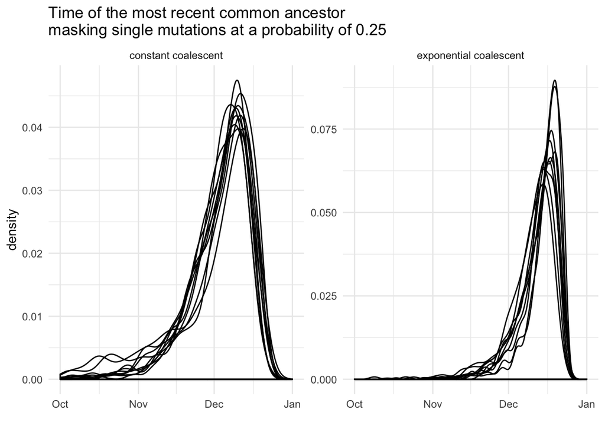

```r
p_tmrca = ggplot(expo_dat[which( expo_dat$dates=="true" & expo_dat$masking==0.25), ]) +
  geom_density(aes(x=mrca, group=interaction(masking_rep,growth_prior)),outlier.shape = NA) +
  xlab("")+
  scale_x_date(limits=as.Date(c("2019-10-01", "2020-01-01")))+
  facet_wrap(~growth_prior, ncol=2, scale="free_y")+
  ggtitle("Time of the most recent common ancestor\nmasking single mutations at a probability of 0.25") +
  theme_minimal()
plot(p_tmrca)
```

## R0 estimates using the coalescent with exponential growth

The R0 is computed from the the growth rate using different average duration of infectiousness and the inferred growth rates for the exponential coalescent The computation of the R0 is based on [the equation](https://www.ncbi.nlm.nih.gov/pmc/articles/PMC1766383/pdf/rspb20063754.pdf) and [here](https://tree.bio.ed.ac.uk/wiki/pages/t769F5D1/Relationship_between_R0_and_the_epidemic_growth_rate.html), assuming becoming uninfectious is exponentially distributed with average duration of infectiousness=1/becoming uninfectious rate.

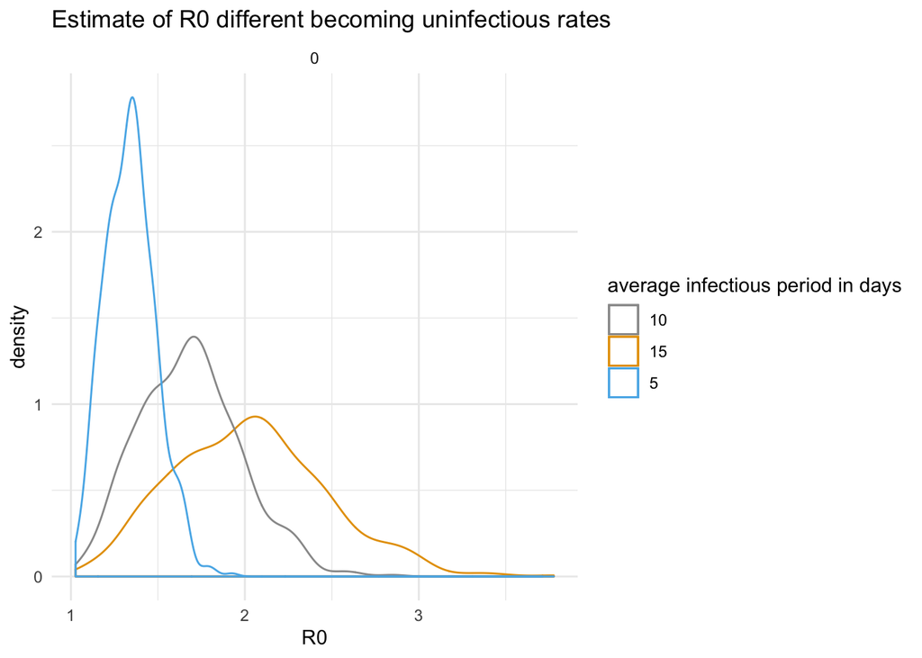

```r
# compute the R0 for different becoming uninfectious rates
average_infectious = c(15, 10, 5)

becomin_uninfectious = 1/average_infectious*365

expo_dat$R0 = 1+expo_dat$growthRate/36.5


p_R0 = ggplot(expo_dat[which(expo_dat$dates=="true" & expo_dat$growth_prior=="exponential coalescent" & expo_dat$masking==0), ]) +
  geom_density(aes(x=(1+growthRate/becomin_uninfectious[[1]]), color=factor(average_infectious[1]))) +
  geom_density(aes(x=(1+growthRate/becomin_uninfectious[[2]]), color=factor(average_infectious[2]))) +
  geom_density(aes(x=(1+growthRate/becomin_uninfectious[[3]]), color=factor(average_infectious[3]))) +
  xlab("")+
  facet_wrap(~masking, ncol=2) +
  ggtitle("Estimate of R0 different becoming uninfectious rates") +
  xlab("R0")+
  theme_minimal()+
  scale_color_manual(values=c('#999999','#E69F00', '#56B4E9'), name="average infectious period in days")
  # theme(legend.title = element_text("average infectious period in days"))
plot(p_R0)
```

## Genome data used

These analyses have been made possible by the public sharing of data. The analysis here used the following sequences

| Accession | Strain | Sampling.Times | Lab | Authors |
| --- | --- | --- | --- | --- |
| EPI_ISL_403933 | Guangdong/20SF013/2020 | 2020-01-15 | Department of Microbiology, Guangdong Provincial Center for Diseases Control and Prevention; Guangdong Provinical Public Health, Guangzhou, China | Kang et al |
| EPI_ISL_403935 | Guangdong/20SF025/2020 | 2020-01-15 | Department of Microbiology, Guangdong Provincial Center for Diseases Control and Prevention; Guangdong Provinical Public Health, Guangzhou, China | Kang et al |
| EPI_ISL_403932 | Guangdong/20SF012/2020 | 2020-01-14 | Department of Microbiology, Guangdong Provincial Center for Diseases Control and Prevention; Guangdong Provinical Public Health, Guangzhou, China | Kang et al |
| EPI_ISL_406593 | Shenzhen/SZTH-002/2020 | 2020-01-13 | Shenzhen Key Laboratory of Pathogen and Immunity, National Clinical Research Center for Infectious Disease, Shenzhen, China | Yang et al |
| EPI_ISL_403962 | Nonthaburi/61/2020 | 2020-01-08 | Department of Medical Sciences, National Institute of Health, Nonthaburi, Thailand | Pilailuk et al |
| EPI_ISL_404228 | Zhejiang/WZ-02/2020 | 2020-01-17 | Department of Microbiology, Zhejiang Provincial Center for Disease Control and Prevention, Hangzhou, China | Zhang et al |
| EPI_ISL_406538 | Guangdong/20SF201/2020 | 2020-01-23 | Guangdong Provincial Center for Diseases Control and Prevention, Guangzhou, China | Kang et al |
| ? | WHU01 | 2020-01-02 | ? | Chen et al |
| EPI_ISL_403963 | Nonthaburi/74/2020 | 2020-01-13 | Department of Medical Sciences, National Institute of Health, Nonthaburi, Thailand | Pilailuk et al |
| EPI_ISL_402119 | Wuhan/IVDC-HB-01/2019 | 2019-12-30 | National Institute for Viral Disease Control and Prevention, China CDC, Beijing, China | Tan et al |
| ? | WHU02 | 2020-01-02 | ? | Chen et al |
| EPI_ISL_402129 | Wuhan/WIV06/2019 | 2019-12-30 | Wuhan Institute of Virology, Chinese Academy of Sciences, Wuhan, China | Zhou et al |
| EPI_ISL_403929 | Wuhan/IPBCAMS-WH-04/2019 | 2019-12-30 | Institute of Pathogen Biology, Chinese Academy of Medical Sciences & Peking Union Medical College, Beijing, China | Ren et al |
| EPI_ISL_402124 | Wuhan/WIV04/2019 | 2019-12-30 | Wuhan Institute of Virology, Chinese Academy of Sciences, Wuhan, China | Zhou et al |
| EPI_ISL_402128 | Wuhan/WIV05/2019 | 2019-12-30 | Wuhan Institute of Virology, Chinese Academy of Sciences, Wuhan, China | Zhou et al |
| EPI_ISL_406534 | Foshan/20SF207/2020 | 2020-01-22 | Guangdong Provincial Center for Diseases Control and Prevention, Guangzhou, China | Kang et al |
| EPI_ISL_406596 | France/IDF0372/2020 | 2020-01-23 | National Reference Center for Viruses of Respiratory Infections, Institut Pasteur, Paris, France | Albert et al |
| EPI_ISL_406036 | USA/CA2/2020 | 2020-01-22 | Pathogen Discovery, Respiratory Viruses Branch, Division of Viral Diseases, Centers for Dieases Control and Prevention, Atlanta GA, USA | Uehara et al |
| EPI_ISL_402132 | Wuhan/HBCDC-HB-01/2019 | 2019-12-30 | Hubei Provincial Center for Disease Control and Prevention, Wuhan, China | Fang et al |
| EPI_ISL_406597 | France/IDF0373/2020 | 2020-01-23 | National Reference Center for Viruses of Respiratory Infections, Institut Pasteur, Paris, France | Albert et al |
| EPI_ISL_406223 | USA/AZ1/2020 | 2020-01-22 | Pathogen Discovery, Respiratory Viruses Branch, Division of Viral Diseases, Centers for Disease Control and Prevention, Atlanta, GA, USA | Tao et al |
| EPI_ISL_406034 | USA/CA1/2020 | 2020-01-23 | Pathogen Discovery, Respiratory Viruses Branch, Division of Viral Diseases, Centers for Dieases Control and Prevention, Atlanta GA, USA | Uehara et al |
| EPI_ISL_406533 | Guangzhou/20SF206/2020 | 2020-01-22 | Guangdong Provincial Center for Diseases Control and Prevention, Guangzhou, China | Kang et al |
| EPI_ISL_402123 | Wuhan/IPBCAMS-WH-01/2019 | 2019-12-24 | Institute of Pathogen Biology, Chinese Academy of Medical Sciences & Peking Union Medical College, Beijing, China | Ren et al |
| EPI_ISL_402121 | Wuhan/IVDC-HB-05/2019 | 2019-12-30 | National Institute for Viral Disease Control and Prevention, China CDC, Beijing, China | Tan et al |
| EPI_ISL_402125 | Wuhan-Hu-1/2019 | 2019-12-26 | National Institute for Communicable Disease Control and Prevention (ICDC), China CDC, Beijing, China | Zhang et al |
| EPI_ISL_404227 | Zhejiang/WZ-01/2020 | 2020-01-16 | Department of Microbiology, Zhejiang Provincial Center for Disease Control and Prevention, Hangzhou, China | Chen et al |
| EPI_ISL_406535 | Foshan/20SF210/2020 | 2020-01-22 | Guangdong Provincial Center for Diseases Control and Prevention, Guangzhou, China | Kang et al |
| EPI_ISL_406031 | Taiwan/2/2020 | 2020-01-23 | Centers for Disease Control, R.O.C., Taipei, Taiwan | Yang et al |
| EPI_ISL_404253 | USA/IL1/2020 | 2020-01-21 | Pathogen Discovery, Respiratory Viruses Branch, Division of Viral Diseases, Centers for Dieases Control and Prevention, Atlanta, GA | Tao et al |
| EPI_ISL_406595 | Shenzhen/SZTH-004/2020 | 2020-01-16 | Shenzhen Key Laboratory of Pathogen and Immunity, National Clinical Research Center for Infectious Disease, Shenzhen, China | Yang et al |
| EPI_ISL_402127 | Wuhan/WIV02/2019 | 2019-12-30 | Wuhan Institute of Virology, Chinese Academy of Sciences, Wuhan, China | Zhou et al |
| EPI_ISL_406536 | Foshan/20SF211/2020 | 2020-01-22 | Guangdong Provincial Center for Diseases Control and Prevention, Guangzhou, China | Kang et al |
| EPI_ISL_404895 | USA-WA1/2020 | 2020-01-19 | ? | Queen et al |
| EPI_ISL_402130 | Wuhan/WIV07/2019 | 2019-12-30 | Wuhan Institute of Virology, Chinese Academy of Sciences, Wuhan, China | Zhou et al |
| EPI_ISL_403931 | Wuhan/IPBCAMS-WH-02/2019 | 2019-12-30 | Institute of Pathogen Biology, Chinese Academy of Medical Sciences & Peking Union Medical College, Beijing, China | Ren et al |
| EPI_ISL_403934 | Guangdong/20SF014/2020 | 2020-01-15 | Department of Microbiology, Guangdong Provincial Center for Diseases Control and Prevention; Guangdong Provinical Public Health, Guangzhou, China | Kang et al |
| EPI_ISL_403930 | Wuhan/IPBCAMS-WH-03/2019 | 2019-12-30 | Institute of Pathogen Biology, Chinese Academy of Medical Sciences & Peking Union Medical College, Beijing, China | Ren et al |
| EPI_ISL_402120 | Wuhan/IVDC-HB-04/2020 | 2020-01-01 | National Institute for Viral Disease Control and Prevention, China CDC, Beijing, China | Tan et al |
| EPI_ISL_406594 | Shenzhen/SZTH-003/2020 | 2020-01-16 | Shenzhen Key Laboratory of Pathogen and Immunity, National Clinical Research Center for Infectious Disease, Shenzhen, China | Yang et al |
| EPI_ISL_403936 | Guangdong/20SF028/2020 | 2020-01-17 | Department of Microbiology, Guangdong Provincial Center for Diseases Control and Prevention; Guangdong Provinical Public Health, Guangzhou, China | Kang et al |
| EPI_ISL_406531 | Guangdong/20SF174/2020 | 2020-01-22 | Guangdong Provincial Center for Diseases Control and Prevention, Guangzhou, China | Kang et al |
| EPI_ISL_403937 | Guangdong/20SF040/2020 | 2020-01-18 | Department of Microbiology, Guangdong Provincial Center for Diseases Control and Prevention; Guangdong Provinical Public Health, Guangzhou, China | Kang et al |